# Homework#2

Fahad Alsehami

03/03/2022

### The goals of this assigment is to perform exploratory data analysis, then building machine learning models that been taken for the class up the wekk #6 to make a prediction of the outcome along with performance models and selections:

## Dataset information: Breast Cancer

#### Description:

The *breast-cancer-wisconsin.data* including features are computed from a digitized image of a fine needle aspirate (FNA) of a breast mass. They describe characteristics of the cell nuclei present in the image.

Separating plane described above was obtained using Multisurface Method-Tree (MSM-T) [K. P. Bennett, “Decision Tree Construction Via Linear Programming.” Proceedings of the 4th Midwest Artificial Intelligence and Cognitive Science Society, pp. 97-101, 1992], a classification method which uses linear programming to construct a decision tree. Relevant features were selected using an exhaustive search in the space of 1-4 features and 1-3 separating planes.

The actual linear program used to obtain the separating plane in the 3-dimensional space is that described in: [K. P. Bennett and O. L. Mangasarian: “Robust Linear Programming Discrimination of Two Linearly Inseparable Sets”, Optimization Methods and Software 1, 1992, 23-34].

## Attribute Information:

- Sample code number id number
- Clump Thickness 1 - 10
- Uniformity of Cell Size 1 - 10
- Uniformity of Cell Shape 1 - 10
- Marginal Adhesion 1 - 10
- Single Epithelial Cell Size 1 - 10
- Bare Nuclei 1 - 10
- Bland Chromatin 1 - 10
- Normal Nucleoli 1 - 10
- Mitoses 1 - 10
- Class: (2 for benign, 4 for malignant)

## Required libraries for this assigment:

## Part 1: Reading dataset and EDA

### Read dataset from github repo:

```r
#Read dataset from https://archive.ics.uci.edu/ml/datasets/breast+cancer+wisconsin+(original)
x <- getURL("https://archive.ics.uci.edu/ml/machine-learning-databases/breast-cancer-wisconsin/breast-cancer-wisconsin.data")
df <- read.csv(text = x)
#dw.potability <- read.csv("./Data/drinking_water_potability.csv", header = TRUE, sep = ",")%>% glimpse()#using glimpse to have a quick look t the variables we have and the dimensions of the dataset
#head(breast_cancer)
```

```r
variabl_name <- colnames(df)
colnames(df) <- c("id", "thickness", "uc_size", "uc_shape", "marginal", "se_size", "nuclei", "chromatin", "nor_nucleoli", "mitoses", "class")

description <- c("is_number", "clump_thickness", "uniform_cell_size", "uniform_cell_shape", "marginal_adhesion", "single_epithelial_size", "bare_nuclei", "bland_chromatin", "normal_nucleoli", "mitoses", "class")



df_description <- data.frame(cbind(variabl_name, description))

kable(head(df_description),booktabs =T)%>%kable_styling(latex_options ="striped")
```

| variabl_name | description |
| --- | --- |
| X1000025 | is_number |
| X5 | clump_thickness |
| X1 | uniform_cell_size |
| X1.1 | uniform_cell_shape |
| X1.2 | marginal_adhesion |
| X2 | single_epithelial_size |

```r
head(df)
```

|  | id | thickness | uc_size | uc_shape | marginal | se_size | nuclei | chromatin | nor_nucleoli | mitoses | class |
| --- | --- | --- | --- | --- | --- | --- | --- | --- | --- | --- | --- |
| 1 | 1002945 | 5 | 4 | 4 | 5 | 7 | 10 | 3 | 2 | 1 | 2 |
| 2 | 1015425 | 3 | 1 | 1 | 1 | 2 | 2 | 3 | 1 | 1 | 2 |
| 3 | 1016277 | 6 | 8 | 8 | 1 | 3 | 4 | 3 | 7 | 1 | 2 |
| 4 | 1017023 | 4 | 1 | 1 | 3 | 2 | 1 | 3 | 1 | 1 | 2 |
| 5 | 1017122 | 8 | 10 | 10 | 8 | 7 | 10 | 9 | 7 | 1 | 4 |
| 6 | 1018099 | 1 | 1 | 1 | 1 | 2 | 10 | 3 | 1 | 1 | 2 |

```r
str(df)
```

```
'data.frame':   698 obs. of  11 variables:
 $ id          : int  1002945 1015425 1016277 1017023 1017122 1018099 1018561 1033078 1033078 1035283 ...
 $ thickness   : int  5 3 6 4 8 1 2 2 4 1 ...
 $ uc_size     : int  4 1 8 1 10 1 1 1 2 1 ...
 $ uc_shape    : int  4 1 8 1 10 1 2 1 1 1 ...
 $ marginal    : int  5 1 1 3 8 1 1 1 1 1 ...
 $ se_size     : int  7 2 3 2 7 2 2 2 2 1 ...
 $ nuclei      : chr  "10" "2" "4" "1" ...
 $ chromatin   : int  3 3 3 3 9 3 3 1 2 3 ...
 $ nor_nucleoli: int  2 1 7 1 7 1 1 1 1 1 ...
 $ mitoses     : int  1 1 1 1 1 1 1 5 1 1 ...
 $ class       : int  2 2 2 2 4 2 2 2 2 2 ...
```

```r
#using janitor library to clean_names function to:
#Returns names with only lowercase letters, with _ as a separator
#Handles special characters and spaces
#Appends numbers to duplicated names
#Converts “%” to “percent” to retain meaning
df1 <- df1 %>%
  mutate(class = as.factor(class), nuclei = as.integer(nuclei)) %>% #convert Int to factor in *Potability* feature
  clean_names() %>% glimpse()
```

```
Rows: 698
Columns: 11
$ id           <int> 1002945, 1015425, 1016277, 1017023, 1017122, 1018099, 10…
$ thickness    <int> 5, 3, 6, 4, 8, 1, 2, 2, 4, 1, 2, 5, 1, 8, 7, 4, 4, 10, 6…
$ uc_size      <int> 4, 1, 8, 1, 10, 1, 1, 1, 2, 1, 1, 3, 1, 7, 4, 1, 1, 7, 1…
$ uc_shape     <int> 4, 1, 8, 1, 10, 1, 2, 1, 1, 1, 1, 3, 1, 5, 6, 1, 1, 7, 1…
$ marginal     <int> 5, 1, 1, 3, 8, 1, 1, 1, 1, 1, 1, 3, 1, 10, 4, 1, 1, 6, 1…
$ se_size      <int> 7, 2, 3, 2, 7, 2, 2, 2, 2, 1, 2, 2, 2, 7, 6, 2, 2, 4, 2,…
$ nuclei       <int> 10, 2, 4, 1, 10, 10, 1, 1, 1, 1, 1, 3, 3, 9, 1, 1, 1, 10…
$ chromatin    <int> 3, 3, 3, 3, 9, 3, 3, 1, 2, 3, 2, 4, 3, 5, 4, 2, 3, 4, 3,…
$ nor_nucleoli <int> 2, 1, 7, 1, 7, 1, 1, 1, 1, 1, 1, 4, 1, 5, 3, 1, 1, 1, 1,…
$ mitoses      <int> 1, 1, 1, 1, 1, 1, 1, 5, 1, 1, 1, 1, 1, 4, 1, 1, 1, 2, 1,…
$ class        <fct> Benign, Benign, Benign, Benign, Malignant, Benign, Benig…
```

### Now, our features changed to lower cases and converted *class* to factor & *nuclei* as integer. I alos noticed that we have NAs values, and will perform an imputation

```r
summary(df1[, 2: 10]) # **id** is just an identifier of the patient
```

[output not shown]

```r
df1 %>%
  summarise_all(~ sum(is.na(.)))
```

[output not shown]

```r
str(completed.df)
```

```
'data.frame':   698 obs. of  11 variables:
 $ id          : int  1002945 1015425 1016277 1017023 1017122 1018099 1018561 1033078 1033078 1035283 ...
 $ thickness   : int  5 3 6 4 8 1 2 2 4 1 ...
 $ uc_size     : int  4 1 8 1 10 1 1 1 2 1 ...
 $ uc_shape    : int  4 1 8 1 10 1 2 1 1 1 ...
 $ marginal    : int  5 1 1 3 8 1 1 1 1 1 ...
 $ se_size     : int  7 2 3 2 7 2 2 2 2 1 ...
 $ nuclei      : chr  "10" "2" "4" "1" ...
 $ chromatin   : int  3 3 3 3 9 3 3 1 2 3 ...
 $ nor_nucleoli: int  2 1 7 1 7 1 1 1 1 1 ...
 $ mitoses     : int  1 1 1 1 1 1 1 5 1 1 ...
 $ class       : chr  "Benign" "Benign" "Benign" "Benign" ...
```

## It looks we have minor NAs in the feature *nuclei*, which is nearly 2% of the total data points we have in our dataset. As proportion of the dataset, it could not be that damage. However, I need consider it as it is related to an important feature. Therefore, I will perform an imputation for those NAs value with the the mean of *nuclei*’s values

[output not shown]

| thickness | uc_size | uc_shape | marginal | se_size | nuclei | chromatin | nor_nucleoli | mitoses | class |
| --- | --- | --- | --- | --- | --- | --- | --- | --- | --- |
| 5 | 4 | 4 | 5 | 7 | 10 | 3 | 2 | 1 | 2 |
| 3 | 1 | 1 | 1 | 2 | 2 | 3 | 1 | 1 | 2 |
| 6 | 8 | 8 | 1 | 3 | 4 | 3 | 7 | 1 | 2 |
| 4 | 1 | 1 | 3 | 2 | 1 | 3 | 1 | 1 | 2 |
| 8 | 10 | 10 | 8 | 7 | 10 | 9 | 7 | 1 | 4 |
| 1 | 1 | 1 | 1 | 2 | 10 | 3 | 1 | 1 | 2 |
| 2 | 1 | 2 | 1 | 2 | 1 | 3 | 1 | 1 | 2 |
| 2 | 1 | 1 | 1 | 2 | 1 | 1 | 1 | 5 | 2 |
| 4 | 2 | 1 | 1 | 2 | 1 | 2 | 1 | 1 | 2 |
| 1 | 1 | 1 | 1 | 1 | 1 | 3 | 1 | 1 | 2 |

[output cut: 688 more lines]

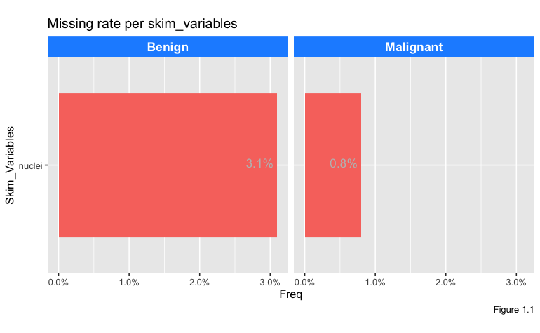

```r
p1 <- df1 %>%
  group_by(class) %>%  skim() %>%
  filter(n_missing != 0) %>%
  as_tibble() %>%
  dplyr::select(skim_variable, n_missing, complete_rate, class) %>%
  mutate(missing_rate = round(abs(complete_rate - 1) * 100, 1)) %>%
  ggplot(aes(
    x = fct_reorder(skim_variable, n_missing),
    y = missing_rate,
    fill = skim_variable,
    label = paste0(missing_rate, "%")
  )) +
  geom_col(width = .8) +
  geom_text(
    size = 4.2,
    hjust = 1.12,
    vjust = 0.20,
    col = "grey"
  ) +
  coord_flip() +
  facet_wrap(vars(class)) +
  theme(aspect.ratio = .9) +
  theme(
    legend.position = "none",
    strip.background = element_rect(fill="dodgerblue1"),
    strip.text = element_text(color = "white", face = "bold", size = 12)
  ) +
  scale_y_continuous(label = label_percent(scale = 1)) +
  scale_colour_gradient(low = "orange", high = "red", na.value = NA) +
  labs(
    title = "Missing rate per skim_variables",
    caption = "Figure 1.1",
    x = "Skim_Variables",
    y = "Freq"
  )
p1
```

### Based on (Figure 1.1), the propotion of the missing values per the targeted feature *class* which i have identified before:

- **class 2** ~ 3.1%
- **class 4** ~ 0.8%

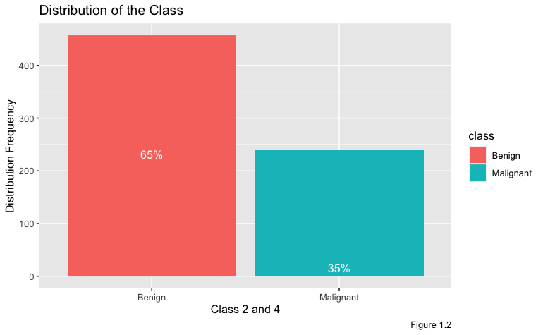

```r
p2 <- df1 %>%
  dplyr::select(class) %>%
  count(class) %>%
  mutate(percent = paste0(round(n / sum(n) * 100), "%"), 2) %>%
  ggplot(aes(
    x = class,
    y = n,
    label = percent,
    fill = class,
  )) +
  geom_col() +
  geom_text(vjust =  15, color = "#ffffff") +
  scale_colour_gradient(
  low = "#132B43",
  high = "#56B1F7",
  space = "Lab",
  na.value = "grey50",
  guide = "colourbar",
  aesthetics = "colour") +
  labs(
    title = "Distribution of the Class",
    x = "Class 2 and 4",
    y = "Distribution Frequency",
    caption = "Figure 1.2"
  )
p2
```

### Distribution between two classes are unbalanced!

### Based on (Figure 1.2), ### The *class* insight shows that we have:

- *class 2* is about 65%
- *class 4* is about 35%

### Part 2: Imputation Methods for the NAs value:

1. Mean imputation

```r
#create a new vector to Impute the missing values with the mean which is a naive solution to make this missing values filled
#Imputation method 1: mean
mean.df <- df3 %>%
  group_by(class) %>%
  mutate(across(where(is.numeric), ~if_else(is.na(.), mean(., na.rm = T), as.numeric(.)))) %>%
  ungroup()

head(mean.df)
```

| thickness | uc_size | uc_shape | marginal | se_size | nuclei | chromatin | nor_nucleoli | mitoses | class |
| --- | --- | --- | --- | --- | --- | --- | --- | --- | --- |
| 5 | 4 | 4 | 5 | 7 | 10 | 3 | 2 | 1 | 2 |
| 3 | 1 | 1 | 1 | 2 | 2 | 3 | 1 | 1 | 2 |
| 6 | 8 | 8 | 1 | 3 | 4 | 3 | 7 | 1 | 2 |
| 4 | 1 | 1 | 3 | 2 | 1 | 3 | 1 | 1 | 2 |
| 8 | 10 | 10 | 8 | 7 | 10 | 9 | 7 | 1 | 4 |
| 1 | 1 | 1 | 1 | 2 | 10 | 3 | 1 | 1 | 2 |

```r
mean.df$class <- factor(mean.df$class, levels=c(2,4), label=c(0,1))
#mean.df
```

```r
mean.df <- mean.df %>%
  mutate(class = as.factor(class), nuclei = as.integer(nuclei)) %>% #convert Int to factor in *Potability* feature
  clean_names() %>% glimpse()
```

```
Rows: 698
Columns: 10
$ thickness    <dbl> 5, 3, 6, 4, 8, 1, 2, 2, 4, 1, 2, 5, 1, 8, 7, 4, 4, 10, 6…
$ uc_size      <dbl> 4, 1, 8, 1, 10, 1, 1, 1, 2, 1, 1, 3, 1, 7, 4, 1, 1, 7, 1…
$ uc_shape     <dbl> 4, 1, 8, 1, 10, 1, 2, 1, 1, 1, 1, 3, 1, 5, 6, 1, 1, 7, 1…
$ marginal     <dbl> 5, 1, 1, 3, 8, 1, 1, 1, 1, 1, 1, 3, 1, 10, 4, 1, 1, 6, 1…
$ se_size      <dbl> 7, 2, 3, 2, 7, 2, 2, 2, 2, 1, 2, 2, 2, 7, 6, 2, 2, 4, 2,…
$ nuclei       <int> 10, 2, 4, 1, 10, 10, 1, 1, 1, 1, 1, 3, 3, 9, 1, 1, 1, 10…
$ chromatin    <dbl> 3, 3, 3, 3, 9, 3, 3, 1, 2, 3, 2, 4, 3, 5, 4, 2, 3, 4, 3,…
$ nor_nucleoli <dbl> 2, 1, 7, 1, 7, 1, 1, 1, 1, 1, 1, 4, 1, 5, 3, 1, 1, 1, 1,…
$ mitoses      <dbl> 1, 1, 1, 1, 1, 1, 1, 5, 1, 1, 1, 1, 1, 4, 1, 1, 1, 2, 1,…
$ class        <fct> 0, 0, 0, 0, 1, 0, 0, 0, 0, 0, 0, 1, 0, 1, 1, 0, 0, 1, 0,…
```

```r
#Imputation method 2: feature imputation
feature_imputation <- kNN(df, k = 5, variable = c("nuclei"))

head(feature_imputation)
```

|  | id | thickness | uc_size | uc_shape | marginal | se_size | nuclei | chromatin | nor_nucleoli | mitoses | class | nuclei_imp |
| --- | --- | --- | --- | --- | --- | --- | --- | --- | --- | --- | --- | --- |
| 1 | 1002945 | 5 | 4 | 4 | 5 | 7 | 10 | 3 | 2 | 1 | 2 | FALSE |
| 2 | 1015425 | 3 | 1 | 1 | 1 | 2 | 2 | 3 | 1 | 1 | 2 | FALSE |
| 3 | 1016277 | 6 | 8 | 8 | 1 | 3 | 4 | 3 | 7 | 1 | 2 | FALSE |
| 4 | 1017023 | 4 | 1 | 1 | 3 | 2 | 1 | 3 | 1 | 1 | 2 | FALSE |
| 5 | 1017122 | 8 | 10 | 10 | 8 | 7 | 10 | 9 | 7 | 1 | 4 | FALSE |
| 6 | 1018099 | 1 | 1 | 1 | 1 | 2 | 10 | 3 | 1 | 1 | 2 | FALSE |

```r
features.NAs <- df %>%
  is.na(.) %>%
  colSums() %>%
  sort(decreasing = FALSE) %>%
  names()
```

#Correlation shows how strong relationship between features, however, it is not the optimal and we need to bring more insightful correlation information: As a result, will construct a method to find out more informative needed for the correlation:

```r
#This function to compute the correlation
corr <- function(mean.df) {
   # r, n, and P matricies as data frame
   M <- Hmisc::rcorr(as.matrix(mean.df)) #rcorr is Pearson or Spearman correlation matrix with pairwise deletion of missing data. However, it looks we don have a continuous feature which violate one or more of the *Pearson* rules
   # L will return 3 data frames
   L <- map(M, ~data.frame(.x))
}


#Show the correlation between all features
corr(mean.df) %>% first() %>% head() %>% kable()
```

|  | thickness | uc_size | uc_shape | marginal | se_size | nuclei | chromatin | nor_nucleoli | mitoses | class |
| --- | --- | --- | --- | --- | --- | --- | --- | --- | --- | --- |
| thickness | 1.0000000 | 0.6453664 | 0.6550888 | 0.4866987 | 0.5221081 | 0.5935238 | 0.5585115 | 0.5361762 | 0.3501762 | 0.7165085 |
| uc_size | 0.6453664 | 1.0000000 | 0.9068137 | 0.7053970 | 0.7516745 | 0.6914868 | 0.7558236 | 0.7226987 | 0.4585481 | 0.8177715 |
| uc_shape | 0.6550888 | 0.9068137 | 1.0000000 | 0.6828713 | 0.7195237 | 0.7136609 | 0.7360655 | 0.7192723 | 0.4387555 | 0.8187940 |
| marginal | 0.4866987 | 0.7053970 | 0.6828713 | 1.0000000 | 0.5994023 | 0.6704341 | 0.6667593 | 0.6031323 | 0.4174761 | 0.6966048 |
| se_size | 0.5221081 | 0.7516745 | 0.7195237 | 0.5994023 | 1.0000000 | 0.5854889 | 0.6161079 | 0.6287036 | 0.4789749 | 0.6826184 |
| nuclei | 0.5935238 | 0.6914868 | 0.7136609 | 0.6704341 | 0.5854889 | 1.0000000 | 0.6806888 | 0.5840221 | 0.3390050 | 0.8225632 |
| chromatin | 0.5585115 | 0.7558236 | 0.7360655 | 0.6667593 | 0.6161079 | 0.6806888 | 1.0000000 | 0.6659143 | 0.3441181 | 0.7567322 |
| nor_nucleoli | 0.5361762 | 0.7226987 | 0.7192723 | 0.6031323 | 0.6287036 | 0.5840221 | 0.6659143 | 1.0000000 | 0.4281854 | 0.7120671 |
| mitoses | 0.3501762 | 0.4585481 | 0.4387555 | 0.4174761 | 0.4789749 | 0.3390050 | 0.3441181 | 0.4281854 | 1.0000000 | 0.4230081 |
| class | 0.7165085 | 0.8177715 | 0.8187940 | 0.6966048 | 0.6826184 | 0.8225632 | 0.7567322 | 0.7120671 | 0.4230081 | 1.0000000 |

```r
NA
```

### Bellow will start a new approache to plot more informative correlation

```r
#Will create tow features list to measure the correlations between those features and map them out!
corr(mean.df) %>%
 map(~rownames_to_column(.x, var="features1")) %>%
 # format each data set (r,P,n) long
 map(~pivot_longer(.x, -features1, "features2")) %>%
 # look at the first element of the list (r)
 first() %>%
 head() %>%
 kable()
```

| features1 | features2 | value |
| --- | --- | --- |
| thickness | thickness | 1.0000000 |
| thickness | uc_size | 0.6453664 |
| thickness | uc_shape | 0.6550888 |
| thickness | marginal | 0.4866987 |
| thickness | se_size | 0.5221081 |
| thickness | nuclei | 0.5935238 |
| thickness | chromatin | 0.5585115 |
| thickness | nor_nucleoli | 0.5361762 |
| thickness | mitoses | 0.3501762 |
| thickness | class | 0.7165085 |
| uc_size | thickness | 0.6453664 |
| uc_size | uc_size | 1.0000000 |
| uc_size | uc_shape | 0.9068137 |
| uc_size | marginal | 0.7053970 |
| uc_size | se_size | 0.7516745 |
| uc_size | nuclei | 0.6914868 |
| uc_size | chromatin | 0.7558236 |
| uc_size | nor_nucleoli | 0.7226987 |
| uc_size | mitoses | 0.4585481 |
| uc_size | class | 0.8177715 |
| uc_shape | thickness | 0.6550888 |
| uc_shape | uc_size | 0.9068137 |
| uc_shape | uc_shape | 1.0000000 |
| uc_shape | marginal | 0.6828713 |
| uc_shape | se_size | 0.7195237 |
| uc_shape | nuclei | 0.7136609 |
| uc_shape | chromatin | 0.7360655 |
| uc_shape | nor_nucleoli | 0.7192723 |
| uc_shape | mitoses | 0.4387555 |
| uc_shape | class | 0.8187940 |

[output cut: 70 more lines]

```r
corr_function <- function(mean.df){
 corr(mean.df) %>%
 map(~rownames_to_column(.x, var="feature1")) %>% # Set (r = correlation ,P = p-value,n = sample size)
 map(~pivot_longer(.x, -feature1, "feature2")) %>% # Bind and merge feature1, feature2, value, and group them by id
 bind_rows(.id = "id") %>%
 pivot_wider(names_from = id, values_from = value) %>%
 mutate(sig_p = ifelse(P < .05, T, F), p_if_sig = ifelse(P <.05, P, NA), r_if_sig = ifelse(P <.05, r, NA))
}


#Call the function
corr_function(mean.df) %>% head() %>% kable()
```

| feature1 | feature2 | r | n | P | sig_p | p_if_sig | r_if_sig |
| --- | --- | --- | --- | --- | --- | --- | --- |
| thickness | thickness | 1.0000000 | 698 | NA | NA | NA | NA |
| thickness | uc_size | 0.6453664 | 698 | 0 | TRUE | 0 | 0.6453664 |
| thickness | uc_shape | 0.6550888 | 698 | 0 | TRUE | 0 | 0.6550888 |
| thickness | marginal | 0.4866987 | 698 | 0 | TRUE | 0 | 0.4866987 |
| thickness | se_size | 0.5221081 | 698 | 0 | TRUE | 0 | 0.5221081 |
| thickness | nuclei | 0.5935238 | 682 | 0 | TRUE | 0 | 0.5935238 |

```r
NA
```

#now, we can plot the correlation function

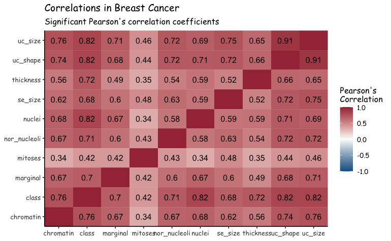

```r
corr_function(mean.df) %>%
 ggplot(aes(feature1, feature2, fill=r, label=round(r_if_sig,2))) +
 geom_tile() +
 labs(x = NULL, y = NULL, fill = "Pearson's\nCorrelation", title="Correlations in Breast Cancer", subtitle="Significant Pearson's correlation coefficients") +
 scale_fill_gradient2(mid="#FBFEF9",low="#0C6291",high="#A63446", limits=c(-1,1)) +
 geom_text() +
 theme_classic() +
 scale_x_discrete(expand=c(0,0)) +
 scale_y_discrete(expand=c(0,0)) +
 theme(text=element_text(family="Comic Sans MS"))
```

### uc_size and uc_shape have good indecation of correlations

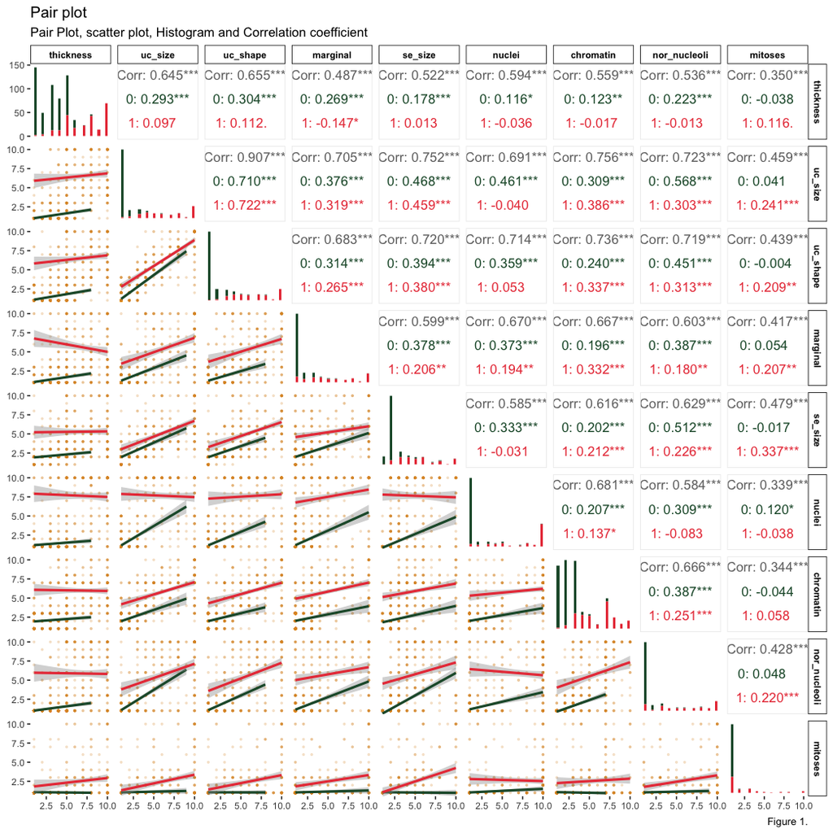

```r
ggpairs(
  mean.df,
  aes(color = class),
  columns = 1:9,
  lower = list(continuous = wrap(
    "smooth",
    alpha = 0.2,
    size = 0.5,
    color = "#DE942E"
  )),
  diag = list(continuous = "barDiag"),
  upper = list(continuous = wrap("cor", size = 4))
) +
  scale_color_manual(values = c("#1F5736", "#E94046")) +
  scale_fill_manual(values = c("#1F5736", "#E94046")) +
  theme(
    axis.text = element_text(size = 8),
    panel.background = element_rect(fill = "white"),
    strip.background = element_rect(fill = "white"),
    strip.background.x = element_rect(colour = "black"),
    strip.background.y = element_rect(colour = "black"),
    strip.text = element_text(color = "black", face = "bold", size = 8)
  ) +
  labs(
    title = "Pair plot",
    subtitle = "Pair Plot, scatter plot, Histogram and Correlation coefficient",
    caption = "Figure 1.",
    x = NULL,
    y = NULL
  )
```

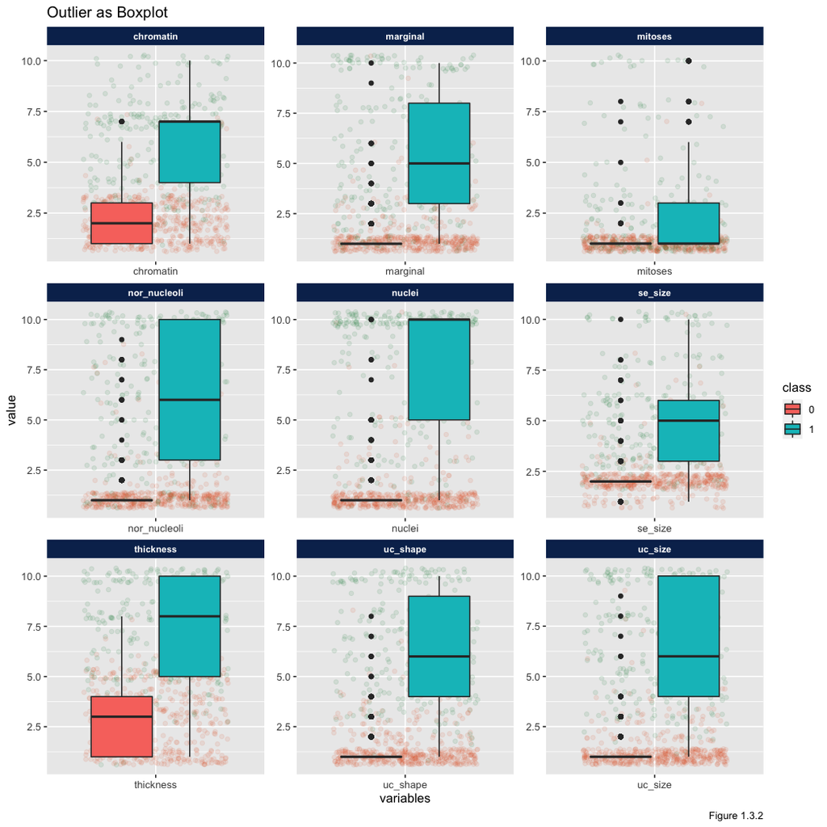

```r
p3 <- mean.df %>%
  pivot_longer(cols = -class, names_to = "variables") %>%
  ggplot(aes(x = variables, y = value)) +
  geom_jitter(aes(y = value, col = class), alpha = 0.1) + # It adds a small amount of random variation to the location of each point, and is a useful way of handling overplotting caused by discreteness in smaller datasets.
  geom_boxplot(aes(fill = class)) +
  facet_wrap(vars(variables), ncol = 3, scales = "free") +
  scale_color_manual(values = c("#E4652E", "#0E8A41")) +
  #scale_colour_gradient(low = "orange", high = "red", na.value = NA) +
  theme(
    legend.position = "right",
    strip.background = element_rect(fill = "#0B2D5B"),
    strip.text = element_text(color = "white", face = "bold", size = 8)
  ) +
  labs(
    title = "Outlier as Boxplot",
    caption = "Figure 1.3.2"
  )
p3
```

```r
df_corr
```

```
             thickness   uc_size  uc_shape  marginal   se_size nuclei
thickness    1.0000000 0.6453664 0.6550888 0.4866987 0.5221081     NA
uc_size      0.6453664 1.0000000 0.9068137 0.7053970 0.7516745     NA
uc_shape     0.6550888 0.9068137 1.0000000 0.6828713 0.7195237     NA
marginal     0.4866987 0.7053970 0.6828713 1.0000000 0.5994023     NA
se_size      0.5221081 0.7516745 0.7195237 0.5994023 1.0000000     NA
nuclei              NA        NA        NA        NA        NA      1
chromatin    0.5585115 0.7558236 0.7360655 0.6667593 0.6161079     NA
nor_nucleoli 0.5361762 0.7226987 0.7192723 0.6031323 0.6287036     NA
mitoses      0.3501762 0.4585481 0.4387555 0.4174761 0.4789749     NA
             chromatin nor_nucleoli   mitoses
thickness    0.5585115    0.5361762 0.3501762
uc_size      0.7558236    0.7226987 0.4585481
uc_shape     0.7360655    0.7192723 0.4387555
marginal     0.6667593    0.6031323 0.4174761
se_size      0.6161079    0.6287036 0.4789749
nuclei              NA           NA        NA
chromatin    1.0000000    0.6659143 0.3441181
nor_nucleoli 0.6659143    1.0000000 0.4281854
mitoses      0.3441181    0.4281854 1.0000000
```

```r
#Randomly divided mean.df (dataset imputed by the mean)into a training  80% and a validation 20%


#df1$class <- factor(df1$class, levels=c("Benign","Malignant"), label=c(0,1))

set.seed(1234)

train <- sample(nrow(mean.df), 0.8*nrow(df2))
df.train <- df2[train,]
df.validation <-df2[-train,]


df.train$class <- as.factor(df.train$class)
df.validation$class <- as.factor(df.validation$class)

ctr <- trainControl(method="cv",
                           number = 15,
                           classProbs = TRUE,
                           summaryFunction = twoClassSummary)
```

### Part 3: Building Models:

- 3.1 Model 1: logst.model <- Logistic regression
- 3.2 Model 2: svm.model <- SVM
- 3.3 Model 3: knn.model <- KNN
- 3.4 Model 4: rf.model <- Random Forest

```r
cm.rf
```

```
Confusion Matrix and Statistics

           Reference
Prediction  Benign Malignant
  Benign        98         3
  Malignant      4        35

               Accuracy : 0.95
                 95% CI : (0.8997, 0.9797)
    No Information Rate : 0.7286
    P-Value [Acc > NIR] : 1.155e-11

                  Kappa : 0.8746

 Mcnemar's Test P-Value : 1

            Sensitivity : 0.9211
            Specificity : 0.9608
         Pos Pred Value : 0.8974
         Neg Pred Value : 0.9703
             Prevalence : 0.2714
         Detection Rate : 0.2500
   Detection Prevalence : 0.2786
      Balanced Accuracy : 0.9409

       'Positive' Class : Malignant
```

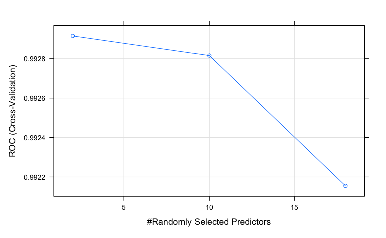

```r
plot(rf.model)
```

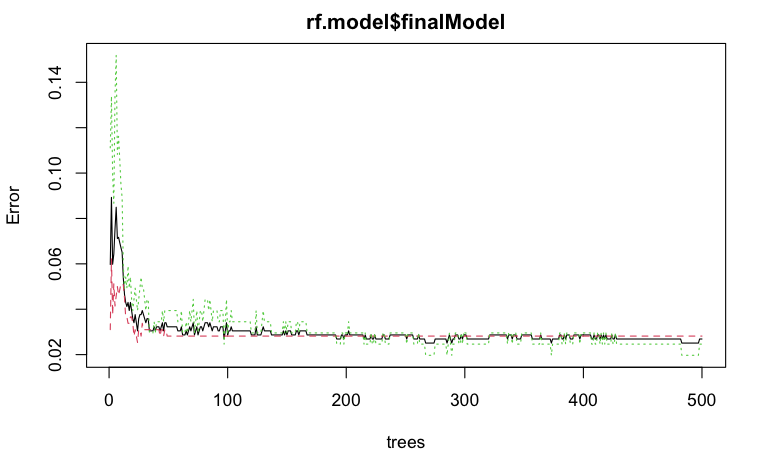

```r
plot(rf.model$finalModel)
```

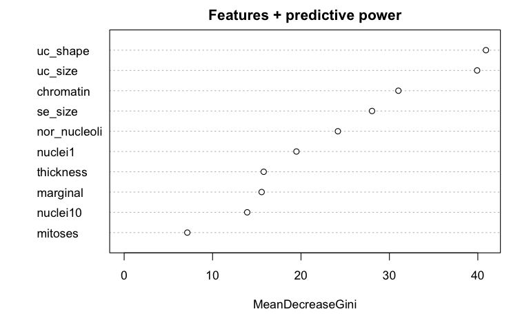

```r
randomForest::varImpPlot(rf.model$finalModel, sort = TRUE,
           n.var = 10, main = "Features + predictive power")
```

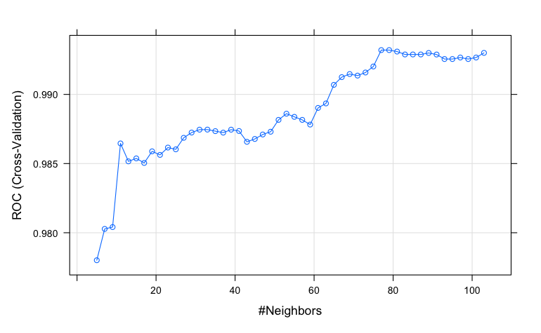

```r
knn.model <- train(class ~., data = df.train,
                      method = "knn",
                      metric = "ROC",
                      preProcess = c("scale", "center"),
                      trControl = ctr,
                      tuneLength =50)

plot(knn.model)
```

```r
pred.knn <- predict(knn.model, df.validation)
cm.knn <- confusionMatrix(pred.knn, df.validation$class, "Malignant")
cm.knn
```

```
Confusion Matrix and Statistics

           Reference
Prediction  Benign Malignant
  Benign       101         6
  Malignant      1        32

               Accuracy : 0.95
                 95% CI : (0.8997, 0.9797)
    No Information Rate : 0.7286
    P-Value [Acc > NIR] : 1.155e-11

                  Kappa : 0.8681

 Mcnemar's Test P-Value : 0.1306

            Sensitivity : 0.8421
            Specificity : 0.9902
         Pos Pred Value : 0.9697
         Neg Pred Value : 0.9439
             Prevalence : 0.2714
         Detection Rate : 0.2286
   Detection Prevalence : 0.2357
      Balanced Accuracy : 0.9162

       'Positive' Class : Malignant
```

```r
set.seed(12345)
svm.model <- train(class ~., data = df.train, method = "svmLinear",
                      metric = "ROC",
                      preProcess = c("scale", "center"),
                      trace = FALSE,
                      trControl = ctr)

pred.svm <- predict(svm.model, df.validation)
cm.svm <- confusionMatrix(pred.svm, df.validation$class, "Malignant")
cm.svm
```

```
Confusion Matrix and Statistics

           Reference
Prediction  Benign Malignant
  Benign        97         2
  Malignant      5        36

               Accuracy : 0.95
                 95% CI : (0.8997, 0.9797)
    No Information Rate : 0.7286
    P-Value [Acc > NIR] : 1.155e-11

                  Kappa : 0.8766

 Mcnemar's Test P-Value : 0.4497

            Sensitivity : 0.9474
            Specificity : 0.9510
         Pos Pred Value : 0.8780
         Neg Pred Value : 0.9798
             Prevalence : 0.2714
         Detection Rate : 0.2571
   Detection Prevalence : 0.2929
      Balanced Accuracy : 0.9492

       'Positive' Class : Malignant
```

```r
cm.svm.pca
```

```
Confusion Matrix and Statistics

           Reference
Prediction  Benign Malignant
  Benign        98         3
  Malignant      4        35

               Accuracy : 0.95
                 95% CI : (0.8997, 0.9797)
    No Information Rate : 0.7286
    P-Value [Acc > NIR] : 1.155e-11

                  Kappa : 0.8746

 Mcnemar's Test P-Value : 1

            Sensitivity : 0.9211
            Specificity : 0.9608
         Pos Pred Value : 0.8974
         Neg Pred Value : 0.9703
             Prevalence : 0.2714
         Detection Rate : 0.2500
   Detection Prevalence : 0.2786
      Balanced Accuracy : 0.9409

       'Positive' Class : Malignant
```

# Model Evaluation:

```r
summary(evaulations)
```

```
Call:
summary.resamples(object = evaulations)

Models: logisic, rf, svm, SVM_with_PCA
Number of resamples: 15

ROC
                  Min.   1st Qu.    Median      Mean 3rd Qu. Max. NA's
logisic      0.9440994 0.9892598 1.0000000 0.9885206       1    1    0
rf           0.9732143 0.9892399 0.9970238 0.9929149       1    1    0
svm          0.9487179 0.9892150 0.9940476 0.9914337       1    1    0
SVM_with_PCA 0.9519231 0.9851190 1.0000000 0.9908690       1    1    0

Sens
                  Min.   1st Qu.    Median      Mean 3rd Qu. Max. NA's
logisic      0.8695652 0.9565217 1.0000000 0.9713768       1    1    0
rf           0.9166667 0.9574275 0.9583333 0.9693237       1    1    0
svm          0.8750000 0.9565217 0.9583333 0.9690821       1    1    0
SVM_with_PCA 0.9130435 0.9583333 1.0000000 0.9747585       1    1    0

Spec
                  Min.   1st Qu.    Median      Mean 3rd Qu. Max. NA's
logisic      0.8461538 0.9258242 0.9285714 0.9402930       1    1    0
rf           0.9230769 0.9642857 1.0000000 0.9802198       1    1    0
svm          0.7857143 0.8516484 1.0000000 0.9366300       1    1    0
SVM_with_PCA 0.7142857 0.8901099 1.0000000 0.9465201       1    1    0
```

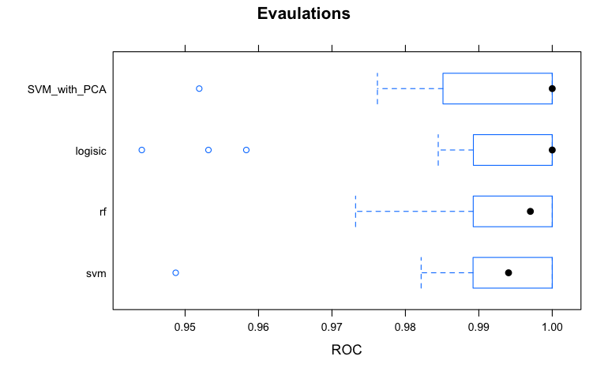

### Logistic model has variability as indecated in the Evaluation figure, random forest model is best one.

```r
cm_nnetlda_df
```

```
Confusion Matrix and Statistics

           Reference
Prediction  Benign Malignant
  Benign        97         2
  Malignant      5        36

               Accuracy : 0.95
                 95% CI : (0.8997, 0.9797)
    No Information Rate : 0.7286
    P-Value [Acc > NIR] : 1.155e-11

                  Kappa : 0.8766

 Mcnemar's Test P-Value : 0.4497

            Sensitivity : 0.9474
            Specificity : 0.9510
         Pos Pred Value : 0.8780
         Neg Pred Value : 0.9798
             Prevalence : 0.2714
         Detection Rate : 0.2571
   Detection Prevalence : 0.2929
      Balanced Accuracy : 0.9492

       'Positive' Class : Malignant
```

| Sensitivity | Specificity | Pos Pred Value | Neg Pred Value | Precision | Recall | F1 | Prevalence | Detection Rate | Detection Prevalence | Balanced Accuracy |
| --- | --- | --- | --- | --- | --- | --- | --- | --- | --- | --- |
| 0.9210526 | 0.9607843 | 0.8974359 | 0.970297 | 0.8974359 | 0.9210526 | 0.9090909 | 0.2714286 | 0.2500000 | 0.2785714 | 0.9409185 |
| 0.9210526 | 0.9607843 | 0.8974359 | 0.970297 | 0.8974359 | 0.9210526 | 0.9090909 | 0.2714286 | 0.2500000 | 0.2785714 | 0.9409185 |
| 0.9473684 | 0.9509804 | 0.8780488 | 0.979798 | 0.8780488 | 0.9473684 | 0.9113924 | 0.2714286 | 0.2571429 | 0.2928571 | 0.9491744 |
| 0.9736842 | 0.9705882 | 0.9250000 | 0.990000 | 0.9250000 | 0.9736842 | 0.9487179 | 0.2714286 | 0.2642857 | 0.2857143 | 0.9721362 |